# R Notebook

Host and Env drivers of microbiome. This script integrates the Backward Difference Coding’ scheme, allowing me to drop the nestlings subset model of previous analyses.

# Set-up and libraries

```
phyloseq-class experiment-level object
otu_table()   OTU Table:         [ 54343 taxa and 246 samples ]
sample_data() Sample Data:       [ 246 samples by 50 sample variables ]
tax_table()   Taxonomy Table:    [ 54343 taxa by 7 taxonomic ranks ]
refseq()      DNAStringSet:      [ 54343 reference sequences ]
```

# Data cleaning

```r
numeric.predictors <- c("QubitDNA","Tarsus","Weight", "wing", "broodSizeWhenSampled", "broodSizeMax", "totalFledge", "clutchSize", "layDateFirst", "numberDeadPreRinged", "numberDeadPostRinged","scaled.mass","scaled.mass.wing.adult", "scaled.mass.tarsus.adult","scaled.mass.chick", "scaled.mass.tarsus", "scaled.mass.wing", "DistanceToEdge")

# centre and scale numeric variables ie. subtract mean and divide by st. deviation
metadata.scaled <- metadata
metadata.scaled[,numeric.predictors] <- scale(metadata.scaled[,numeric.predictors])

adults.meta.scaled <- adults.meta
adults.meta.scaled[,numeric.predictors] <- scale(adults.meta.scaled[,numeric.predictors])
#
# nestlings.meta.scaled <- nestlings.meta
# nestlings.meta.scaled[,numeric.predictors] <- scale(nestlings.meta.scaled[,numeric.predictors])
```

# All birds shannon global model

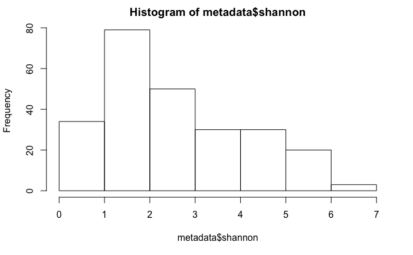

```r
hist(metadata$shannon)
```

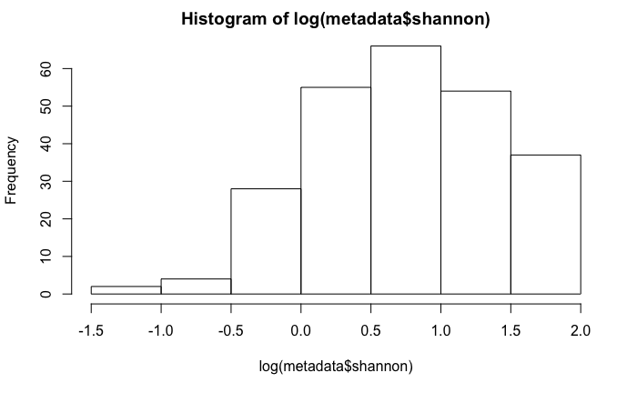

```r
hist(log(metadata$shannon))
```

```r
#table(metadata$ageBinned, metadata$habitat)
```

Plot raw data, diversity by age and habitat.

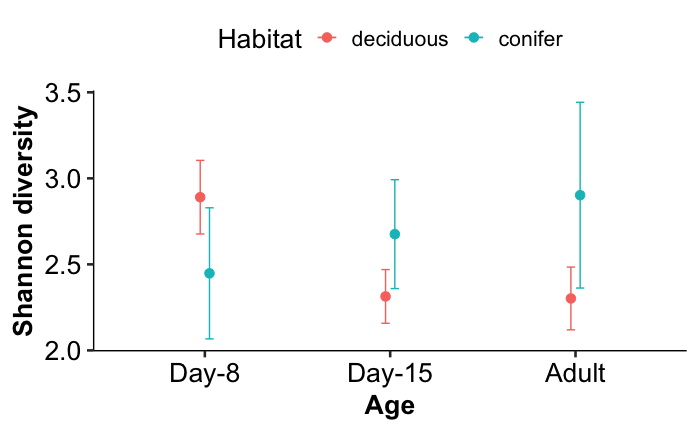

```r
## summarySE provides the standard deviation, standard error of the mean, and a (default 95%) confidence interval
summ.meta <- summarySE(metadata, measurevar="shannon", groupvars=c("habitat","ageBinned"))

# rename cols so plot is nicer
summ.meta <- summ.meta %>% dplyr::rename("Habitat"="habitat")

pd <- position_dodge2(padding = 0.1, width = 0.1)

g1 <- ggplot(summ.meta, aes(x=ageBinned, y=shannon, colour=Habitat)) +
    geom_errorbar(aes(ymin=shannon-se, ymax=shannon+se), width=.1,position=pd) +
    geom_line(position=pd) +
    geom_point(position=pd, size=3) +
    xlab("Age") +
    ylab("Shannon diversity") +
    scale_x_discrete(labels=c("1week"="Day-8", "2week"="Day-15", "adult"="Adult")) +
    theme_pubr(base_size = 20) +
    theme(axis.title = element_text(face="bold"))

g1
```

```r
## geting warning about "one obs." because i am just feeding it the summary stats directly, rather than the raw data
```

Plot shannon diversity to assess normality. Shows right skew. * Both cube-root and Log-shannon is close to normality but H0 rejected by shapiro.

```r
my.backward.diff = matrix(c(-2/3, 1/3, 1/3, -1/3, -1/3, 2/3), ncol = 2)
my.backward.diff
```

```
           [,1]       [,2]
[1,] -0.6666667 -0.3333333
[2,]  0.3333333 -0.3333333
[3,]  0.3333333  0.6666667
```

```r
levels(metadata.scaled$ageBinned) # verify: 1week,2week,adult
```

```
[1] "1week" "2week" "adult"
```

```r
#assigning the backward difference coding to ageBinned
contrasts(metadata.scaled$ageBinned) = my.backward.diff
```

- residuals are better with log(shannon) than untransformed shannon
- ageBinned1 estimate is difference between 2week-1week
- ageBinned2 estimate/coefficient is difference between adult-2week
- what is intercept? Sample mean? or grand mean? Mean of week1?

```r
#metadata.scaled$habitat <- relevel(metadata.scaled$habitat, "conifer")

all.shannon.global <- lmer(log(shannon) ~ ageBinned * habitat * layDateFirst + ageBinned * broodSizeWhenSampled + habitat*DistanceToEdge +  (1|site/nest/bird.ID) + (1|SequencePlate), data = metadata.scaled)
summary(all.shannon.global)
```

```
Linear mixed model fit by REML. t-tests use Satterthwaite's method ['lmerModLmerTest']
Formula: log(shannon) ~ ageBinned * habitat * layDateFirst + ageBinned *
    broodSizeWhenSampled + habitat * DistanceToEdge + (1 | site/nest/bird.ID) +      (1 | SequencePlate)
   Data: metadata.scaled

REML criterion at convergence: 466.1

Scaled residuals:
     Min       1Q   Median       3Q      Max
-3.06258 -0.50122  0.05418  0.64267  2.41107

Random effects:
 Groups              Name        Variance Std.Dev.
 bird.ID:(nest:site) (Intercept) 0.01504  0.1227
 nest:site           (Intercept) 0.07961  0.2822
 site                (Intercept) 0.02996  0.1731
 SequencePlate       (Intercept) 0.03274  0.1809
 Residual                        0.26534  0.5151
Number of obs: 246, groups:  bird.ID:(nest:site), 197; nest:site, 61; site, 9; SequencePlate, 5

Fixed effects:
                                         Estimate Std. Error         df t value Pr(>|t|)
(Intercept)                             7.805e-01  1.304e-01  7.668e+00   5.988 0.000387 ***
ageBinned1                             -2.576e-01  1.087e-01  1.965e+02  -2.369 0.018815 *
ageBinned2                              1.022e-01  1.228e-01  1.997e+02   0.832 0.406254
habitatconifer                          1.178e-02  1.991e-01  1.228e+01   0.059 0.953791
layDateFirst                            5.781e-02  6.234e-02  5.771e+01   0.927 0.357656
broodSizeWhenSampled                   -7.095e-04  5.128e-02  1.090e+02  -0.014 0.988985
DistanceToEdge                          1.484e-01  6.363e-02  5.522e+01   2.332 0.023401 *
ageBinned1:habitatconifer               4.438e-01  2.019e-01  1.311e+02   2.198 0.029704 *
ageBinned2:habitatconifer               1.430e-01  2.975e-01  1.883e+02   0.481 0.631187
ageBinned1:layDateFirst                 2.457e-02  8.490e-02  1.332e+02   0.289 0.772726
ageBinned2:layDateFirst                -5.643e-02  1.214e-01  2.207e+02  -0.465 0.642418
habitatconifer:layDateFirst            -9.335e-02  2.251e-01  3.662e+01  -0.415 0.680805
ageBinned1:broodSizeWhenSampled        -4.431e-02  8.964e-02  1.606e+02  -0.494 0.621805
ageBinned2:broodSizeWhenSampled         1.405e-01  1.111e-01  2.191e+02   1.265 0.207106
habitatconifer:DistanceToEdge          -9.611e-02  1.368e-01  4.125e+01  -0.702 0.486357
ageBinned1:habitatconifer:layDateFirst  2.665e-01  2.315e-01  1.103e+02   1.151 0.252102
ageBinned2:habitatconifer:layDateFirst  1.748e-01  4.359e-01  1.952e+02   0.401 0.688805
---
Signif. codes:  0 ‘***’ 0.001 ‘**’ 0.01 ‘*’ 0.05 ‘.’ 0.1 ‘ ’ 1
```

```
Correlation matrix not shown by default, as p = 17 > 12.
Use print(x, correlation=TRUE)  or
    vcov(x)        if you need it
```

```r
#$Save results in variable
summary.all.shannon.global <- summary(all.shannon.global)[["coefficients"]]
```

```r
simulationOutput <- simulateResiduals(fittedModel = all.shannon.global, n = 250)
```

```
DHARMa: fittedModel not in class of supported models. Absolutely no guarantee that this will work!
```

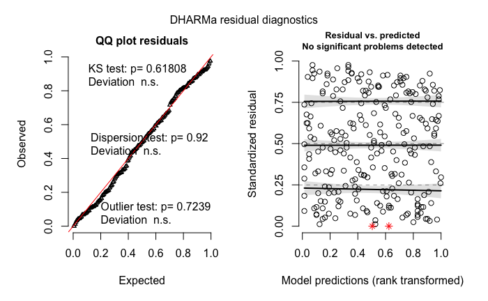

```r
plot(simulationOutput)
```

How does my interpretation of this plot change now that im using Backwards difference coding?

Better plot * why NA values in levels call? * nestlings converge on similar diversity across habitats as they age

```r
all.shannon.global.effects <- effect("ageBinned:habitat", all.shannon.global)
```

```
NOTE: ageBinned:habitat is not a high-order term in the model
```

```r
all.shannon.global.effects <- as.data.frame(effect("ageBinned:habitat", all.shannon.global))
```

```
NOTE: ageBinned:habitat is not a high-order term in the model
```

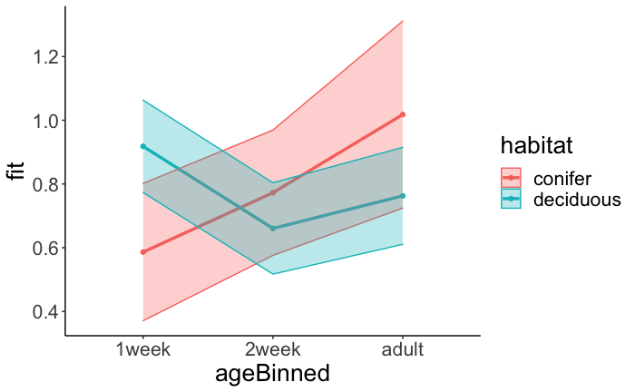

```r
ggplot(all.shannon.global.effects, aes(x=ageBinned, y=fit, color=habitat,group=habitat)) +
    geom_point() +
    geom_line(size=1.2) +
    geom_ribbon(aes(ymin=fit-se, ymax=fit+se, fill=habitat),alpha=0.3) +
    theme_classic() + theme(text=element_text(size=20)) #+labs(title = "Reactivity by Daily Control Beliefs", x= "Daily Stressor (0=Did not occur, 1=Occurred)", y="Negative Affect", color="Daily Control Beliefs", fill="Daily Control Beliefs")
```

Plot distance by shannon

```r
effects_distance <- effects::effect(term= c("DistanceToEdge", "habitat"), mod= all.shannon.global)
```

```
longer object length is not a multiple of shorter object lengthlonger object length is not a multiple of shorter object lengthNOTE: DistanceToEdgehabitat is not a high-order term in the model
```

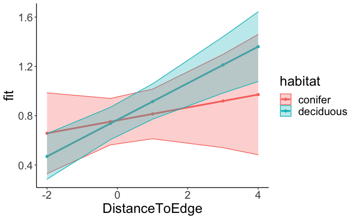

```r
#summary(effects_distance) #output of what the values are

x_dist <- as.data.frame(effects_distance)

ggplot(x_dist, aes(x=DistanceToEdge, y=fit, color=habitat,group=habitat)) +
    geom_point() +
    geom_line(size=1.2) +
    geom_ribbon(aes(ymin=fit-se, ymax=fit+se, fill=habitat),alpha=0.3) +
    theme_classic() + theme(text=element_text(size=20))
```

## Check for outliers

no apparent outliers

```r
summary(metadata$shannon)
```

```
   Min. 1st Qu.  Median    Mean 3rd Qu.    Max.
 0.2494  1.2903  2.1191  2.5316  3.6537  6.7559
```

```r
which(metadata$shannon==max(metadata$shannon)) #172
```

```
[1] 172
```

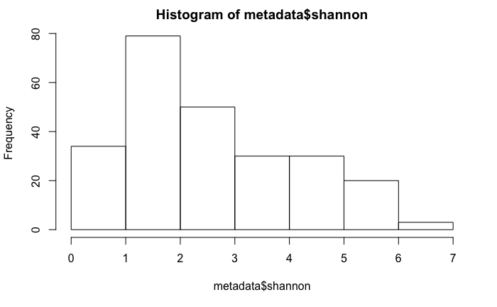

```r
hist(metadata$shannon)
```

# All birds shannon select model

```r
all.shannon.select <-  lmer(log(shannon) ~ ageBinned * habitat + layDateFirst + broodSizeWhenSampled + habitat*DistanceToEdge +  (1|site/nest/bird.ID) + (1|SequencePlate), data = metadata.scaled)
summary(all.shannon.select)
```

```
Linear mixed model fit by REML. t-tests use Satterthwaite's method ['lmerModLmerTest']
Formula: log(shannon) ~ ageBinned * habitat + layDateFirst + broodSizeWhenSampled +
    habitat * DistanceToEdge + (1 | site/nest/bird.ID) + (1 |      SequencePlate)
   Data: metadata.scaled

REML criterion at convergence: 456.4

Scaled residuals:
     Min       1Q   Median       3Q      Max
-3.10545 -0.51122  0.01387  0.60658  2.35251

Random effects:
 Groups              Name        Variance Std.Dev.
 bird.ID:(nest:site) (Intercept) 0.01227  0.1108
 nest:site           (Intercept) 0.07101  0.2665
 site                (Intercept) 0.02423  0.1556
 SequencePlate       (Intercept) 0.03368  0.1835
 Residual                        0.26852  0.5182
Number of obs: 246, groups:  bird.ID:(nest:site), 197; nest:site, 61; site, 9; SequencePlate, 5

Fixed effects:
                                Estimate Std. Error         df t value Pr(>|t|)
(Intercept)                     0.779202   0.125349   8.632735   6.216 0.000186 ***
ageBinned1                     -0.217355   0.104671 198.946284  -2.077 0.039127 *
ageBinned2                      0.074581   0.119481 212.031200   0.624 0.533160
habitatconifer                  0.019929   0.175540  13.191719   0.114 0.911321
layDateFirst                    0.054996   0.055591  50.201159   0.989 0.327259
broodSizeWhenSampled           -0.009575   0.049084 113.461802  -0.195 0.845677
DistanceToEdge                  0.150791   0.061549  58.856817   2.450 0.017282 *
ageBinned1:habitatconifer       0.370569   0.194451 142.824753   1.906 0.058696 .
ageBinned2:habitatconifer       0.173707   0.252488 211.110095   0.688 0.492219
habitatconifer:DistanceToEdge  -0.160813   0.110340  50.755373  -1.457 0.151156
---
Signif. codes:  0 ‘***’ 0.001 ‘**’ 0.01 ‘*’ 0.05 ‘.’ 0.1 ‘ ’ 1

Correlation of Fixed Effects:
            (Intr) agBnn1 agBnn2 hbttcn lyDtFr brdSWS DstnTE agBn1: agBn2:
ageBinned1  -0.032
ageBinned2   0.069 -0.459
habitatcnfr -0.394 -0.037  0.005
layDateFrst  0.015 -0.016  0.046  0.097
brdSzWhnSmp  0.027  0.316 -0.193 -0.120  0.062
DistancTEdg -0.026  0.027 -0.018  0.010 -0.010  0.000
agBnnd1:hbt  0.008 -0.487  0.197 -0.062  0.015 -0.092 -0.009
agBnnd2:hbt -0.052  0.168 -0.406  0.214  0.032  0.094  0.022 -0.257
hbttcnf:DTE  0.013 -0.023  0.003 -0.050 -0.167 -0.088 -0.560 -0.014 -0.078
```

```r
simulationOutput <- simulateResiduals(fittedModel = all.shannon.select, n = 250)
```

```
DHARMa: fittedModel not in class of supported models. Absolutely no guarantee that this will work!
```

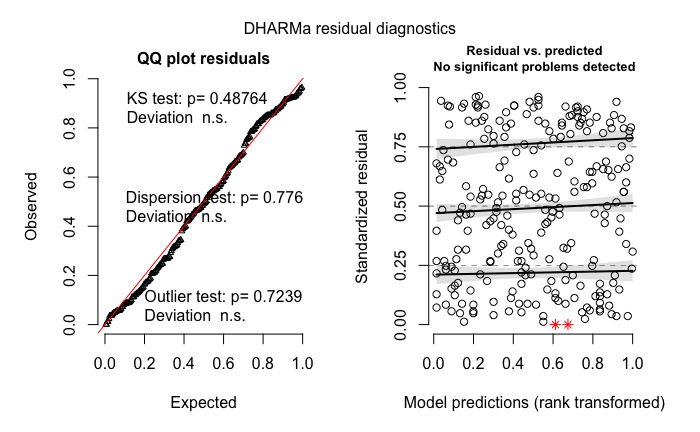

```r
plot(simulationOutput)
```

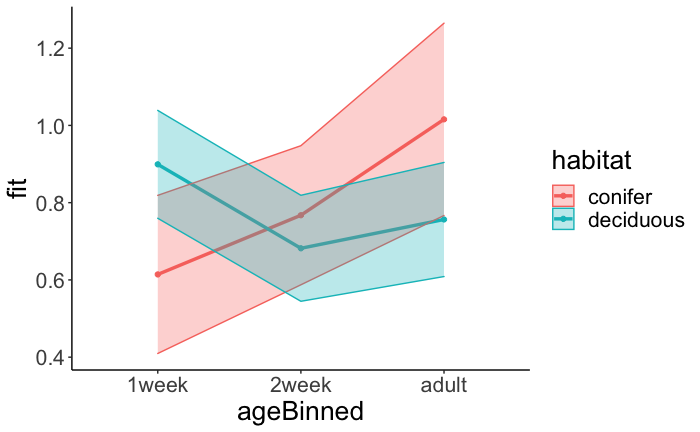

```r
all.shannon.select.effects <- effect("ageBinned:habitat", all.shannon.select)
all.shannon.select.effects <- as.data.frame(effect("ageBinned:habitat", all.shannon.select))

ggplot(all.shannon.select.effects, aes(x=ageBinned, y=fit, color=habitat,group=habitat)) +
    geom_point() +
    geom_line(size=1.2) +
    geom_ribbon(aes(ymin=fit-se, ymax=fit+se, fill=habitat),alpha=0.3) +
    theme_classic() + theme(text=element_text(size=20)) #+labs(title = "Reactivity by Daily Control Beliefs", x= "Daily Stressor (0=Did not occur, 1=Occurred)", y="Negative Affect", color="Daily Control Beliefs", fill="Daily Control Beliefs")
```

Interesting that deciduous birds appear to be more affected by distance to edge than coniferous considering coniferous denser and more homogenous than deciduous. Though maybe this is because all coniferous irds are close to forest edge anyway. Or deciduous sites have different plant and insect species at edge than more internally.

Plot of individual age groups confirms overall trend of neutral effect of distance in conifer and positive effect of distance in deciduous sites.

```r
effects_distance.select <- effects::effect(term= c("DistanceToEdge", "habitat"), mod= all.shannon.select)
```

```
longer object length is not a multiple of shorter object lengthlonger object length is not a multiple of shorter object lengthNOTE: DistanceToEdgehabitat is not a high-order term in the model
```

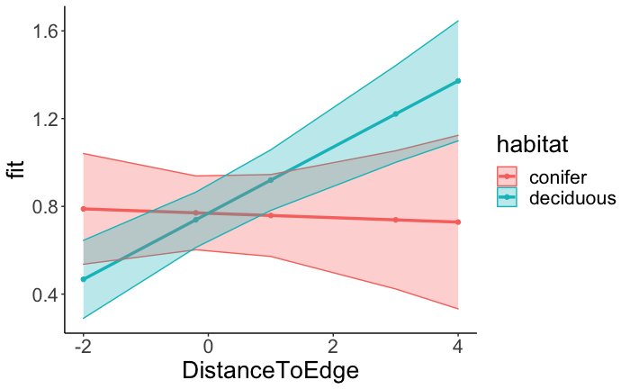

```r
#summary(effects_distance) #output of what the values are

effects_distance.select <- as.data.frame(effects_distance.select)

ggplot(effects_distance.select, aes(x=DistanceToEdge, y=fit, color=habitat, group=habitat)) +
    geom_point() +
    geom_line(size=1.2) +
    geom_ribbon(aes(ymin=fit-se, ymax=fit+se, fill=habitat),alpha=0.3) +
    theme_classic() + theme(text=element_text(size=20))
```

```r
effects_distance.select <- effects::effect(term= c("DistanceToEdge", "habitat", "ageBinned"), mod= all.shannon.select)
```

```
longer object length is not a multiple of shorter object lengthlonger object length is not a multiple of shorter object length
```

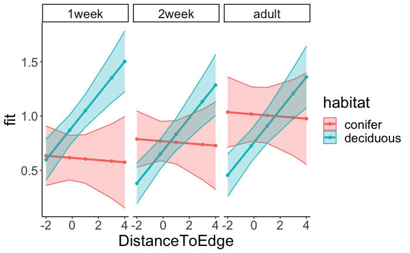

```r
effects_distance.select.ages <- as.data.frame(effects_distance.select)

# consistent across age groups
ggplot(effects_distance.select.ages, aes(x=DistanceToEdge, y=fit, color=habitat, group=habitat)) +
    geom_point() +
    geom_line(size=1.2) +
    geom_ribbon(aes(ymin=fit-se, ymax=fit+se, fill=habitat),alpha=0.3) +
    facet_wrap(~ageBinned) +
    theme_classic() + theme(text=element_text(size=20))
```

# All birds chao1 global model

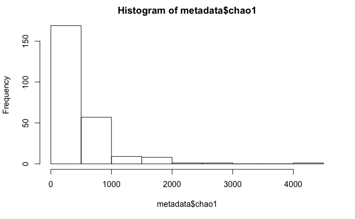

```r
hist(metadata$chao1) # very skewed
```

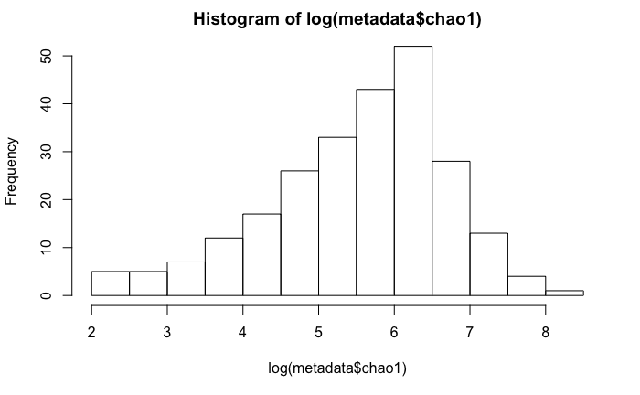

```r
hist(log(metadata$chao1)) # normalish, slight left skew
```

Plot raw data

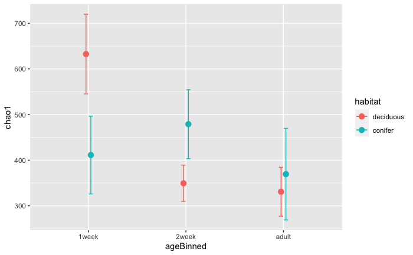

```r
## summarySE provides the standard deviation, standard error of the mean, and a (default 95%) confidence interval
summ.meta <- summarySE(metadata, measurevar="chao1", groupvars=c("habitat","ageBinned"))

pd <- position_dodge2(padding = 0.1, width = 0.1)

g1 <- ggplot(summ.meta, aes(x=ageBinned, y=chao1, colour=habitat)) +
    geom_errorbar(aes(ymin=chao1-se, ymax=chao1+se), width=.1,position=pd) +
    geom_line(position=pd) +
    geom_point(position=pd, size=3)

g1
```

```r
## geting warning about "one obs." because i am just feeding it the summary stats directly, rather than the raw data
```

Singular fit due to individual ID random term

```r
all.chao.global0 <- lmer(log(chao1) ~ ageBinned * habitat * layDateFirst + ageBinned * broodSizeWhenSampled + habitat*DistanceToEdge + (1|site/nest/bird.ID) + (1|SequencePlate), data = metadata.scaled)
```

```
boundary (singular) fit: see ?isSingular
```

```r
summary(all.chao.global0)
```

```
Linear mixed model fit by REML. t-tests use Satterthwaite's method ['lmerModLmerTest']
Formula: log(chao1) ~ ageBinned * habitat * layDateFirst + ageBinned *
    broodSizeWhenSampled + habitat * DistanceToEdge + (1 | site/nest/bird.ID) +      (1 | SequencePlate)
   Data: metadata.scaled

REML criterion at convergence: 710.3

Scaled residuals:
     Min       1Q   Median       3Q      Max
-2.67835 -0.52604  0.03276  0.57698  2.69731

Random effects:
 Groups              Name        Variance Std.Dev.
 bird.ID:(nest:site) (Intercept) 0.00000  0.0000
 nest:site           (Intercept) 0.39423  0.6279
 site                (Intercept) 0.09418  0.3069
 SequencePlate       (Intercept) 0.06663  0.2581
 Residual                        0.75561  0.8693
Number of obs: 246, groups:  bird.ID:(nest:site), 197; nest:site, 61; site, 9; SequencePlate, 5

Fixed effects:
                                         Estimate Std. Error         df t value Pr(>|t|)
(Intercept)                              5.623884   0.219477   7.816555  25.624    8e-09 ***
ageBinned1                              -0.581247   0.185509 213.191926  -3.133  0.00197 **
ageBinned2                               0.037261   0.205994 185.429417   0.181  0.85666
habitatconifer                          -0.112524   0.377451  15.615381  -0.298  0.76954
layDateFirst                             0.002955   0.119860  59.363863   0.025  0.98041
broodSizeWhenSampled                     0.077083   0.093607 129.249742   0.823  0.41175
DistanceToEdge                           0.274666   0.122673  56.430352   2.239  0.02911 *
ageBinned1:habitatconifer                0.788003   0.339952 196.275160   2.318  0.02148 *
ageBinned2:habitatconifer               -0.274848   0.490150 190.211982  -0.561  0.57563
ageBinned1:layDateFirst                  0.120647   0.144638 212.815332   0.834  0.40515
ageBinned2:layDateFirst                  0.049292   0.204981 221.544901   0.240  0.81019
habitatconifer:layDateFirst             -0.279012   0.429212  40.784058  -0.650  0.51930
ageBinned1:broodSizeWhenSampled         -0.002937   0.153389 218.924582  -0.019  0.98474
ageBinned2:broodSizeWhenSampled          0.266513   0.191149 224.253894   1.394  0.16462
habitatconifer:DistanceToEdge           -0.084903   0.261605  46.473912  -0.325  0.74698
ageBinned1:habitatconifer:layDateFirst   0.018772   0.389325 188.001458   0.048  0.96160
ageBinned2:habitatconifer:layDateFirst  -0.230288   0.722129 201.232611  -0.319  0.75013
---
Signif. codes:  0 ‘***’ 0.001 ‘**’ 0.01 ‘*’ 0.05 ‘.’ 0.1 ‘ ’ 1
```

```
Correlation matrix not shown by default, as p = 17 > 12.
Use print(x, correlation=TRUE)  or
    vcov(x)        if you need it
```

```
optimizer (nloptwrap) convergence code: 0 (OK)
boundary (singular) fit: see ?isSingular
```

Drop individual level random term

```r
all.chao.global <- lmer(log(chao1) ~ ageBinned * habitat * layDateFirst + ageBinned * broodSizeWhenSampled + habitat*DistanceToEdge + (1|site/nest) + (1|SequencePlate), data = metadata.scaled)
summary(all.chao.global)
```

```
Linear mixed model fit by REML. t-tests use Satterthwaite's method ['lmerModLmerTest']
Formula: log(chao1) ~ ageBinned * habitat * layDateFirst + ageBinned *
    broodSizeWhenSampled + habitat * DistanceToEdge + (1 | site/nest) +      (1 | SequencePlate)
   Data: metadata.scaled

REML criterion at convergence: 710.3

Scaled residuals:
     Min       1Q   Median       3Q      Max
-2.67835 -0.52604  0.03276  0.57698  2.69731

Random effects:
 Groups        Name        Variance Std.Dev.
 nest:site     (Intercept) 0.39423  0.6279
 site          (Intercept) 0.09418  0.3069
 SequencePlate (Intercept) 0.06663  0.2581
 Residual                  0.75561  0.8693
Number of obs: 246, groups:  nest:site, 61; site, 9; SequencePlate, 5

Fixed effects:
                                         Estimate Std. Error         df t value Pr(>|t|)
(Intercept)                              5.623884   0.219477   7.816586  25.624    8e-09 ***
ageBinned1                              -0.581246   0.185509 213.191953  -3.133  0.00197 **
ageBinned2                               0.037261   0.205994 185.429503   0.181  0.85666
habitatconifer                          -0.112525   0.377450  15.615475  -0.298  0.76954
layDateFirst                             0.002955   0.119860  59.364113   0.025  0.98041
broodSizeWhenSampled                     0.077083   0.093607 129.249914   0.823  0.41175
DistanceToEdge                           0.274666   0.122672  56.430592   2.239  0.02911 *
ageBinned1:habitatconifer                0.788002   0.339952 196.275080   2.318  0.02148 *
ageBinned2:habitatconifer               -0.274848   0.490150 190.211903  -0.561  0.57563
ageBinned1:layDateFirst                  0.120647   0.144638 212.815280   0.834  0.40514
ageBinned2:layDateFirst                  0.049292   0.204981 221.544841   0.240  0.81019
habitatconifer:layDateFirst             -0.279012   0.429211  40.784300  -0.650  0.51930
ageBinned1:broodSizeWhenSampled         -0.002936   0.153389 218.924571  -0.019  0.98475
ageBinned2:broodSizeWhenSampled          0.266512   0.191149 224.253921   1.394  0.16462
habitatconifer:DistanceToEdge           -0.084903   0.261605  46.474152  -0.325  0.74698
ageBinned1:habitatconifer:layDateFirst   0.018772   0.389325 188.001361   0.048  0.96160
ageBinned2:habitatconifer:layDateFirst  -0.230288   0.722129 201.232542  -0.319  0.75013
---
Signif. codes:  0 ‘***’ 0.001 ‘**’ 0.01 ‘*’ 0.05 ‘.’ 0.1 ‘ ’ 1
```

```
Correlation matrix not shown by default, as p = 17 > 12.
Use print(x, correlation=TRUE)  or
    vcov(x)        if you need it
```

OUTLIER TEST SIGNIFICANT RESIDUAL VS PREDICTED A LIL GOOSEY

```r
simulationOutput <- simulateResiduals(fittedModel = all.chao.global, n = 250)
```

```
DHARMa: fittedModel not in class of supported models. Absolutely no guarantee that this will work!
```

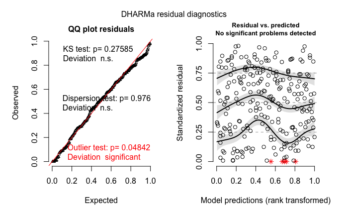

```r
plot(simulationOutput)
```

Is this plot informative on simple age effects or only useful in visualising interaction?

```r
all.chao.global.effects <- effect("ageBinned:habitat", all.chao.global)
```

```
NOTE: ageBinned:habitat is not a high-order term in the model
```

```r
all.chao.global.effects <- as.data.frame(effect("ageBinned:habitat", all.chao.global))
```

```
NOTE: ageBinned:habitat is not a high-order term in the model
```

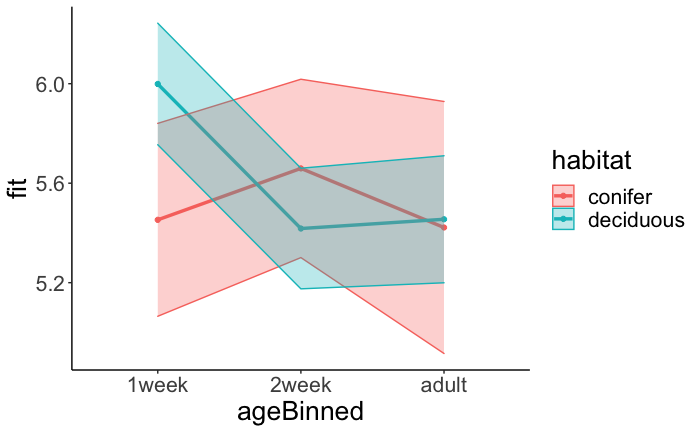

```r
ggplot(all.chao.global.effects, aes(x=ageBinned, y=fit, color=habitat,group=habitat)) +
    geom_point() +
    geom_line(size=1.2) +
    geom_ribbon(aes(ymin=fit-se, ymax=fit+se, fill=habitat),alpha=0.3) +
    theme_classic() + theme(text=element_text(size=20))
```

```r
#+labs(title = "Reactivity by Daily Control Beliefs", x= "Daily Stressor (0=Did not occur, 1=Occurred)", y="Negative Affect", color="Daily Control Beliefs", fill="Daily Control Beliefs")
```

```r
all.chao.global.effects.age <- effect(c("ageBinned","habitat"), all.chao.global)
```

```
longer object length is not a multiple of shorter object lengthlonger object length is not a multiple of shorter object lengthNOTE: ageBinnedhabitat is not a high-order term in the model
```

```r
all.chao.global.effects.age <- as.data.frame(effect(c("ageBinned","habitat"), all.chao.global))
```

```
longer object length is not a multiple of shorter object lengthlonger object length is not a multiple of shorter object lengthNOTE: ageBinnedhabitat is not a high-order term in the model
```

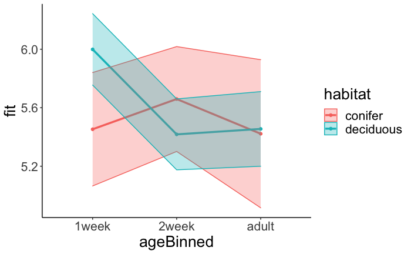

```r
ggplot(all.chao.global.effects.age, aes(x=ageBinned, y=fit, color=habitat, group=habitat)) +
    geom_point() +
    geom_line(size=1.2) +
    geom_ribbon(aes(ymin=fit-se, ymax=fit+se, fill=habitat),alpha=0.3) +
    theme_classic() + theme(text=element_text(size=20))
```

```r
#+labs(title = "Reactivity by Daily Control Beliefs", x= "Daily Stressor (0=Did not occur, 1=Occurred)", y="Negative Affect", color="Daily Control Beliefs", fill="Daily Control Beliefs")
```

# Plot adult alpha diversity

Very few conifer adult samples, particularly when divided by sex

```r
table(adults.meta$habitat, adults.meta$Sex)
```

```
            Fe  M
  deciduous 21 22
  conifer    3  5
```

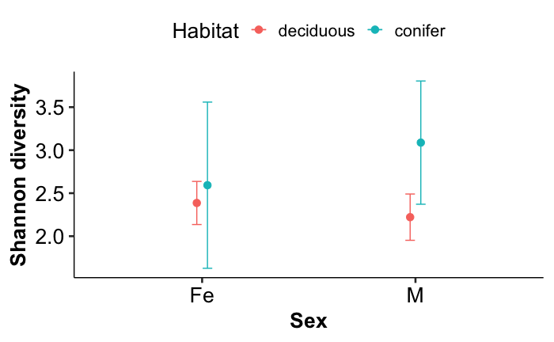

# Adult shannon global model

Model singular when site included as random effect, so dropped for global model * setting REML=T (default) makes signficant terms non-significant

```r
adult.shannon.global <- lmer((shannon)^(1/3) ~ Sex * habitat * broodSizeWhenSampled + Sex * habitat * layDateFirst + habitat * DistanceToEdge + (1|nest) + (1|SequencePlate), data = adults.meta.scaled)
summary(adult.shannon.global)
```

```
Linear mixed model fit by REML. t-tests use Satterthwaite's method ['lmerModLmerTest']
Formula: (shannon)^(1/3) ~ Sex * habitat * broodSizeWhenSampled + Sex *      habitat * layDateFirst + habitat * DistanceToEdge + (1 |
    nest) + (1 | SequencePlate)
   Data: adults.meta.scaled

REML criterion at convergence: 20.5

Scaled residuals:
    Min      1Q  Median      3Q     Max
-1.2389 -0.4597  0.0000  0.4504  1.6014

Random effects:
 Groups        Name        Variance Std.Dev.
 nest          (Intercept) 0.022424 0.1497
 SequencePlate (Intercept) 0.005388 0.0734
 Residual                  0.025998 0.1612
Number of obs: 51, groups:  nest, 38; SequencePlate, 4

Fixed effects:
                                          Estimate Std. Error        df t value Pr(>|t|)
(Intercept)                               1.315758   0.062710  5.864590  20.981 9.67e-07 ***
SexM                                     -0.053060   0.057157 12.209332  -0.928   0.3712
habitatconifer                           -0.328180   0.246142 33.132901  -1.333   0.1915
broodSizeWhenSampled                      0.056078   0.046898 35.477939   1.196   0.2397
layDateFirst                             -0.021535   0.057814 34.882128  -0.372   0.7118
DistanceToEdge                            0.005507   0.038449 29.842319   0.143   0.8871
SexM:habitatconifer                       0.540155   0.292380 31.403963   1.847   0.0741 .
SexM:broodSizeWhenSampled                -0.063661   0.058729 11.486543  -1.084   0.3006
habitatconifer:broodSizeWhenSampled      -0.453810   0.241104 32.353746  -1.882   0.0688 .
SexM:layDateFirst                         0.040264   0.065080 19.584389   0.619   0.5433
habitatconifer:layDateFirst              -0.361925   0.330513 34.070132  -1.095   0.2812
habitatconifer:DistanceToEdge            -0.049702   0.137008 33.254049  -0.363   0.7191
SexM:habitatconifer:broodSizeWhenSampled  0.471232   0.238446 34.588853   1.976   0.0561 .
SexM:habitatconifer:layDateFirst          0.441263   0.284706 28.380521   1.550   0.1322
---
Signif. codes:  0 ‘***’ 0.001 ‘**’ 0.01 ‘*’ 0.05 ‘.’ 0.1 ‘ ’ 1
```

```
Correlation matrix not shown by default, as p = 14 > 12.
Use print(x, correlation=TRUE)  or
    vcov(x)        if you need it
```

```r
simulationOutput <- simulateResiduals(fittedModel = adult.shannon.global, n = 250)
```

```
DHARMa: fittedModel not in class of supported models. Absolutely no guarantee that this will work!
```

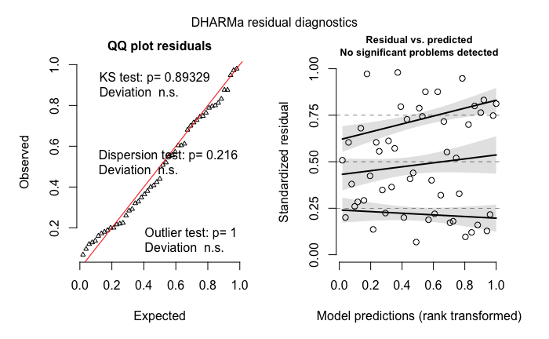

```r
plot(simulationOutput)
```